# Análisis de oportunidades comerciales con IA

### Importamos librerías y cargamos datos

Se trata de un CSV sobre oportunidades comerciales que puedes encontrar [aquí](https://www.kaggle.com/ashydv/leads-dataset)

```python
import pandas as pd
import numpy as np
from sklearn.model_selection import StratifiedKFold, train_test_split
from sklearn.preprocessing import PowerTransformer, OneHotEncoder, RobustScaler, StandardScaler
from sklearn.impute._iterative import IterativeImputer #for numeric values
from sklearn.impute import SimpleImputer #for categorical
import sklearn.feature_selection as feature_selection
from sklearn.pipeline import Pipeline
from sklearn.metrics import f1_score, roc_auc_score, plot_roc_curve, plot_confusion_matrix, confusion_matrix
from sklearn.compose import ColumnTransformer
from sklearn.linear_model import LogisticRegression
import matplotlib.pyplot as plt
import seaborn as sns
import lightgbm as lgb
from category_encoders.target_encoder import TargetEncoder
import utils
pd.set_option('display.max_columns', 100)
pd.set_option('display.max_rows', 1000)
```

```python
data = pd.read_csv('./data/Leads.csv')
label = 'Converted'

data.head()
```

|  | Lead Origin | Lead Source | Do Not Email | Do Not Call | Converted | TotalVisits | Total Time Spent on Website | Page Views Per Visit | Last Activity | Country | Specialization | How did you hear about X Education | What is your current occupation | What matters most to you in choosing a course | Search | Magazine | Newspaper Article | X Education Forums | Newspaper | Digital Advertisement | Through Recommendations | Receive More Updates About Our Courses | Lead Quality | Update me on Supply Chain Content | Get updates on DM Content | Lead Profile | City | Asymmetrique Activity Index | Asymmetrique Profile Index | … |
| --- | --- | --- | --- | --- | --- | --- | --- | --- | --- | --- | --- | --- | --- | --- | --- | --- | --- | --- | --- | --- | --- | --- | --- | --- | --- | --- | --- | --- | --- | --- |
| 0 | API | Olark Chat | No | No | 0 | 0.00 | 0 | 0.00 | Page Visited on Website | NaN | Select | Select | Unemployed | Better Career Prospects | No | No | No | No | No | No | No | No | Low in Relevance | No | No | Select | Select | 02.Medium | 02.Medium | … |
| 1 | API | Organic Search | No | No | 0 | 5.00 | 674 | 2.50 | Email Opened | India | Select | Select | Unemployed | Better Career Prospects | No | No | No | No | No | No | No | No | NaN | No | No | Select | Select | 02.Medium | 02.Medium | … |
| 2 | Landing Page Submission | Direct Traffic | No | No | 1 | 2.00 | 1532 | 2.00 | Email Opened | India | Business Administration | Select | Student | Better Career Prospects | No | No | No | No | No | No | No | No | Might be | No | No | Potential Lead | Mumbai | 02.Medium | 01.High | … |
| 3 | Landing Page Submission | Direct Traffic | No | No | 0 | 1.00 | 305 | 1.00 | Unreachable | India | Media and Advertising | Word Of Mouth | Unemployed | Better Career Prospects | No | No | No | No | No | No | No | No | Not Sure | No | No | Select | Mumbai | 02.Medium | 01.High | … |
| 4 | Landing Page Submission | Google | No | No | 1 | 2.00 | 1428 | 1.00 | Converted to Lead | India | Select | Other | Unemployed | Better Career Prospects | No | No | No | No | No | No | No | No | Might be | No | No | Select | Mumbai | 02.Medium | 01.High | … |

```python
#selecting types of column to process them accordingly
cat_columns = list(data.select_dtypes(include='object').columns)
num_columns = list(set(data.columns) - set(cat_columns))
num_columns.remove(label) #our label should not get in here

#examine nulls
#print(data.shape, '\n', data.isnull().sum())
```

```python
#split data and label
y = data[label]
X = data.drop([label], axis = 1)
```

### Aplicamos KFolds cross-validation y aplicamos las transformaciones y codificaciones en cada paso para evitar data leakage

Hacerse trampas al solitario nunca fue bueno, hay que evitar a toda costa que en los datasets de test / validación aparezca información que ya estaba en el conjunto de entrenamiento, tanto atributos como también normalizaciones o categorías al aplicar transformaciones de datos

```python
#apply cleaning and encoding in EACH phase of the CV process
splitter = StratifiedKFold()

#store results
f1_scores = []
auc_scores = []

#create our own stratified CV loop
for train_index, test_index in splitter.split(X = X, y = y):

    #create estimator
    estim = lgb.LGBMClassifier(n_estimators=500, learning_rate=0.05)

    #separate into train and test for the Knth fold in the split
    X_train_k, X_test_k = X.iloc[train_index], X.iloc[test_index]
    y_train_k, y_test_k = y.iloc[train_index], y.iloc[test_index]

    #clean, transform and encode data in each loop
    X_train_k, X_test_k = utils.transform_data_oh(X_train = X_train_k,
                                X_test = X_test_k,
                                cat_columns = cat_columns,
                                num_columns = num_columns
                                )

    print('data filled and encoded. Shape: ' + str(X_train_k.shape))

    #reduce our dataset, improves stability, speed and interpretability
    X_train_k, X_test_k = utils.apply_RFE(
                                            X_train = X_train_k,
                                            y_train=y_train_k,
                                            X_test=X_test_k,
                                            verbose=False
                                        )

    #fit with the reduced data
    estim.fit(X = X_train_k, y = y_train_k)

    #get results
    preds = estim.predict(X=X_test_k)
    f1 = f1_score(y_true=y_test_k,y_pred=preds)
    auc = roc_auc_score(y_true=y_test_k,y_score=preds)

    f1_scores.append(f1)
    auc_scores.append(auc)

print('F1 average: ' + str(round(np.average(f1_scores), 3)))
print('AUC average: ' + str(round(np.average(auc_scores), 3)))
```

```
data filled and encoded. Shape: (7392, 178)
Fitting estimator with 178 features.
Fitting estimator with 173 features.
Fitting estimator with 168 features.
Fitting estimator with 163 features.
Fitting estimator with 158 features.
Fitting estimator with 153 features.
Fitting estimator with 148 features.
Fitting estimator with 143 features.
Fitting estimator with 138 features.
Fitting estimator with 133 features.
Fitting estimator with 128 features.
Fitting estimator with 123 features.
Fitting estimator with 118 features.
Fitting estimator with 113 features.
Fitting estimator with 108 features.
Fitting estimator with 103 features.
Fitting estimator with 98 features.
Fitting estimator with 93 features.
Fitting estimator with 88 features.
Fitting estimator with 83 features.
Fitting estimator with 78 features.
Fitting estimator with 73 features.
Fitting estimator with 68 features.
Fitting estimator with 63 features.
data filled and encoded. Shape: (7392, 180)
Fitting estimator with 180 features.
Fitting estimator with 175 features.
Fitting estimator with 170 features.
Fitting estimator with 165 features.
Fitting estimator with 160 features.
Fitting estimator with 155 features.
Fitting estimator with 150 features.
Fitting estimator with 145 features.
Fitting estimator with 140 features.
Fitting estimator with 135 features.
Fitting estimator with 130 features.
Fitting estimator with 125 features.
Fitting estimator with 120 features.
Fitting estimator with 115 features.
```

[output cut: 64 more lines]

```
Fitting estimator with 156 features.
Fitting estimator with 151 features.
Fitting estimator with 146 features.
Fitting estimator with 141 features.
Fitting estimator with 136 features.
Fitting estimator with 131 features.
Fitting estimator with 126 features.
Fitting estimator with 121 features.
Fitting estimator with 116 features.
Fitting estimator with 111 features.
Fitting estimator with 106 features.
Fitting estimator with 101 features.
Fitting estimator with 96 features.
F1 average: 0.809
AUC average: 0.846
```

### Selección de variables

Conseguimos consistentemente bajar de 100 features en cada paso del cross validation, por lo que estamos generando modelos más sencillos y robustos, con bastante menos información son capaces de encontrar resultados iguales o mejores. Esto aumenta la velocidad de entrenamiento y la estabilidad del modelo, además de hacerlo más interpretable y usable

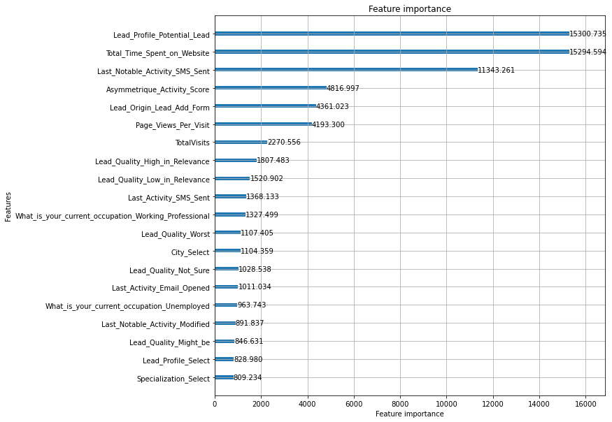

```python
lgb.plot_importance(estim, max_num_features=20, figsize=(10,10), importance_type='gain')
```

```python
import shap
shap.initjs()
```

```python
#extract from the last iteration of K folds, just for demo purposes

explainer = shap.TreeExplainer(estim)
shap_values = explainer.shap_values(X = X_train_k, y = y_train_k)
```

[output not shown]

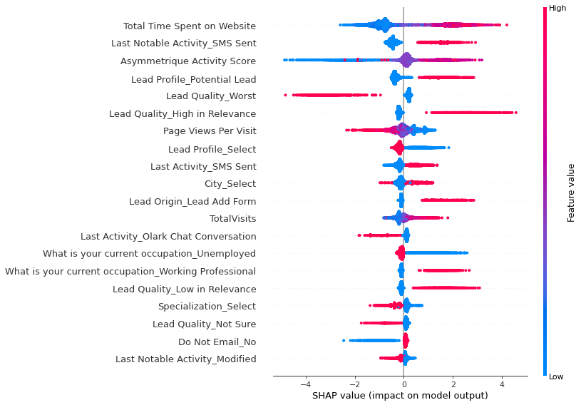

```python
#explanation for cases that actually have been converted into sales
shap.summary_plot(
                    shap_values=shap_values[1], features = X_train_k
                    , feature_names = X_train_k.columns
                    , plot_type = 'dot'
                    )
```

### Interpretabilidad mejorada

```python
#inspect specific cases (right and wrong classified) with decision plots
#create predictions to check which ones are right and which ones are wrong
preds = estim.predict(X_test_k)

confusion_matrix(y_test_k,preds)
```

```
array([[931, 204],
       [109, 604]], dtype=int64)
```

```python
#check other cases
from sklearn.metrics import precision_score
cm = confusion_matrix(y_test_k, preds)

TN = cm[0][0]
FP = cm[0][1]
FN = cm[1][0]
TP = cm[1][1]

print('precision: ' + str(round(precision_score(y_test_k, preds), 3)))

print('negative predictive value : ' + str(round(TN/(TN+FN), 3)))
```

```
precision: 0.748
negative predictive value : 0.895
```

```python
##################################################
##                 DECISION PLOTS               ##
##################################################
right_indices = np.where(preds == y_test_k)[0]
right_cases = X_test_k.iloc[right_indices].head(10)

right_cases_display = X_test_k.loc[right_indices].head(10)

wrong_indices = np.where(preds != y_test_k)[0]
wrong_cases = X_test_k.iloc[wrong_indices].head(10)
```

```python
#correct predictions for the converted cases
shap_values = explainer.shap_values(right_cases)[1]
shap_inter_values = explainer.shap_interaction_values(right_cases)
if isinstance(shap_inter_values, list):
    shap_inter_values = shap_inter_values[1]
```

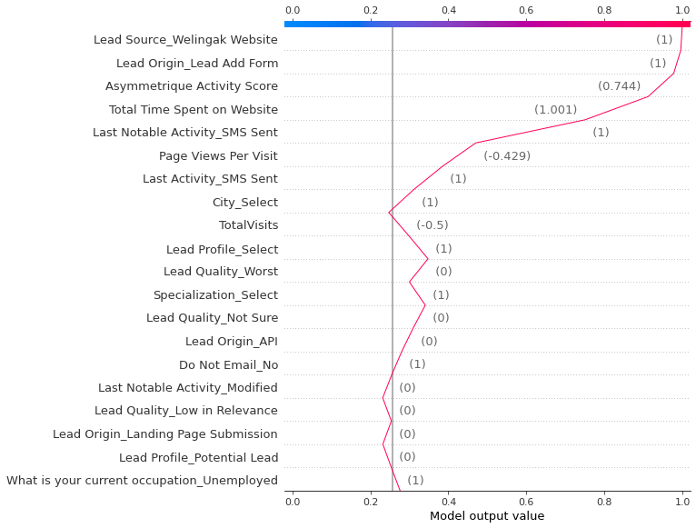

```python
#importance of each feature value (transformed) in the first well classified case
shap.decision_plot(explainer.expected_value, shap_values[0], right_cases, link='logit')
```

### Decision plots para análisis forense de predicciones locales

Los decision plots del paquete SHAP pueden analizar el peso que ha tenido cada uno de los atributos al analizar una predicción determinada. Es útil para análisis post-mortem, auditoría o generación personalizada de acciones

```python
#threshold optimization (simple)
thresholds = np.arange(0.01, 1.0, 0.01)
scores = dict()

#get scores rather than labels
preds_proba = pd.DataFrame(estim.predict_proba(X = X_test_k), columns = ['proba_0', 'proba_1'])
preds_proba = preds_proba['proba_1'] #only proba_1 cases, probability to get the lead done
```

```python
#get adjusted labels
def get_labels(y_scores, t):
    return[1 if y >= t else 0 for y in y_scores]

for t in thresholds:
    predicted_labels = get_labels(preds_proba, t)
    s = f1_score(y_test_k, predicted_labels)
    scores[t] = s

max_threshold = round(max(scores, key=scores.get), 3)
default_score = scores.get(0.5)
print('best threshold is: ' + str(max_threshold))
print('default score is: ' + str(default_score))
```

```
best threshold is: 0.65
default score is: 0.794214332675871
```

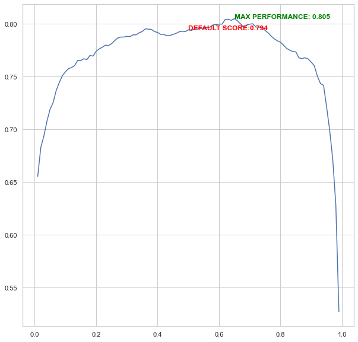

```python
import seaborn as sns

thresholds_plot = list(scores.keys())
scores_plot = list(scores.values())

#plot our gain chart
sns.set(style="whitegrid")
fig = plt.gcf()
fig.set_size_inches(10, 10)
sns_plot = sns.lineplot(x=thresholds_plot, y=scores_plot)
sns_plot.text(max_threshold, max(scores_plot), "MAX PERFORMANCE: " + str(round(max(scores_plot), 3)), weight="bold", color = "green")
sns_plot.text(0.5, default_score, "DEFAULT SCORE:" + str(round(default_score, 3)), weight="bold", color = "red")
```

### Optimización de thresholds

Los clasificadores binarios no siempre resultan totalmente balanceados en sus clasificaciones si ponemos el punto de corte por defecto (0.5). Elegiremos una métrica (idealmente de negocio y asociada a costes y beneficios para poder interpretarla de manera más cercana a negocio) y elegiremos en qué punto de la señal del modelo tenemos el rendimiento optimo